# Community Flooding Sensitivity Analaysis

James Margrove

2 Dezember 2016

Remove everything from the working environment

```r
rm(list = ls())
```

Loading required packages

```r
require(Hmisc)
require(INLA)
require(car)
require(foreach)
require(raster)
```

Upload data, remove unknown species, drop levels and check the data.frame

```r
data<- read.table("Spelev.txt",header = T)
data <- subset(data, sp != "Unkn" & mort != 1 & DBH >50) # remove unknown species
data <- droplevels(data)
str(data)
```

```
## 'data.frame':    4225 obs. of  22 variables:
##  $ tree    : Factor w/ 4225 levels "10HDcau01","10HDcau02",..: 1943 1944 214 1096 1097 1098 1099 1100 1101 1102 ...
##  $ sp      : Factor w/ 42 levels "Acos","Dacu",..: 1 1 2 2 2 2 2 2 2 2 ...
##  $ type    : Factor w/ 2 levels "Emergent","Subcanopy": 1 1 2 2 2 2 2 2 2 2 ...
##  $ Y       : num  5.85 5.85 5.86 5.86 5.86 ...
##  $ X       : num  118 118 118 118 118 ...
##  $ X50N    : num  604904 604919 604793 604819 604793 ...
##  $ Y50N    : num  647180 647169 647441 647268 647366 ...
##  $ X50Nc   : num  604600 604615 604489 604515 604489 ...
##  $ Y50Nc   : num  647119 647108 647381 647207 647305 ...
##  $ elev    : num  33 36 25 30 22 ...
##  $ side    : Factor w/ 2 levels "A1","A2": 1 1 1 1 1 1 1 1 1 1 ...
##  $ fullname: Factor w/ 40 levels "Anisoptera_costata",..: 1 1 2 2 2 2 2 2 2 2 ...
##  $ mlim    : int  50 50 40 40 40 40 40 40 40 40 ...
##  $ dden    : num  0.55 0.55 0.64 0.64 0.64 0.64 0.64 0.64 0.64 0.64 ...
##  $ fsen    : num  NA NA NA NA NA NA NA NA NA NA ...
##  $ habit   : Factor w/ 2 levels "dry","wet": 1 1 1 1 1 1 1 1 1 1 ...
##  $ DBH     : num  75 63 56 80 61.5 ...
##  $ FL2010  : int  0 0 0 1 1 0 0 1 0 0 ...
##  $ FL2014  : int  0 0 0 0 0 0 0 1 0 0 ...
##  $ FL2015  : int  0 0 0 0 1 0 1 0 0 0 ...
##  $ dead    : Factor w/ 1 level "0": 1 1 1 1 1 1 1 1 1 1 ...
##  $ mort    : int  0 0 0 0 0 0 0 0 0 0 ...
```

Cutting the elevation gradient into bands with equal numbers of individuals in. Number of band we want to use = 12;

```r
expected_n_bands <- 12
data$felv25 <- cut2(data$elev, g = expected_n_bands, m = 100)
bands <- cut2(data$elev, g = expected_n_bands, m = 100, onlycuts = TRUE)
bands[c(1,length(bands))] <- c(0,88.4) # set the min and max elevation.
length(bands)-1 # check number of bands.
```

```
## [1] 12
```

Take only the 16 speceis with a flooding sensivity calculated from the seedling water inundation experiment

```r
SP <- c("Dry","Pmal","Ptom","Sacu","Sbec","Sfal","Sgib","Slep","Smac","Smec","Spar","Spau","Ssem","Ssmi","Swal","Sxan")
data <- data[data$sp %in% SP,]
data <- droplevels(data)
```

### To calculate the typical flooding sensitivity of an individual within each band we used INLA-SPDE.

Preparing the mesh. Prior analysis have suggested that this mesh size is a good compormise between precision and computation time.

```r
### Coordinates
coords <- cbind(data$X50N,data$Y50N)
### Mesh
mesh1 <- inla.mesh.2d(coords, max.edge = c(100, 200),
                   cutoff =100,
                   offset=c(200,400))
### Matern Field
spde <- inla.spde2.matern(mesh1)
### A matrix
A <- inla.spde.make.A(mesh1, coords)
```

Combining the data into a stack object.

```r
stk1 <- inla.stack(tag = "stk1",
                   data = list(fsen = data$fsen), # response
                   A = list(A,1),
                   effects = list(list(i = 1:spde$n.spde),
                                  data.frame(int = 1,
                                             felv25 = data$felv25)))
```

Running the INLA-SPDE model

```r
model1 <- inla(fsen ~ -1 + felv25 + f(i, model = spde),
               family = "gaussian",
               data = inla.stack.data(stk1),
               control.predictor = list(A=inla.stack.A(stk1), compute = TRUE),
               control.fixed = list(expand.factor.strategy = "inla"))
```

[output not shown]

[output not shown]

[output not shown]

### To make a map of the flooding sensitivity bands

Import the map and make sure all the parameters are correct

```r
r <- raster("Sepilok160_Qgis.tif") #This is the sepilok, map
e <- extent(603945.651,605788.486,  647133.509,  648054.815) # extent
plot160c <- crop(x = r, e) # placing the map correctly
max(plot160c@data@values)
```

```
## [1] 88.41793
```

```r
plot160c <- plot160c-min(plot160c@data@values)
plot160c <- (plot160c/max(plot160c@data@values))*(88.4)
rVals <- plot160c@data@values # the values of the raster
senPlot <- plot160c # rename the plot senPlot
```

Defining each elevation band from the raster and change the elements in that band to teh appropreate typical flooding sensitivity.

```r
pfsen <- model1$summary.fixed[,1] # The flooding sensitivity values for each band
max(pfsen)/min(pfsen)*100 # the % increase in flooding sensitivity
```

```
## [1] 165.5566
```

Using a loop to put the flooding calculated sensitivity values at the correct location

```r
for(i in 1:length(bands)-1){
cVals <- which(rVals >= bands[i] & rVals <= bands[i+1])
senPlot@data@values[cVals] <- pfsen[i]}
```

Using ggplot to plot the raster

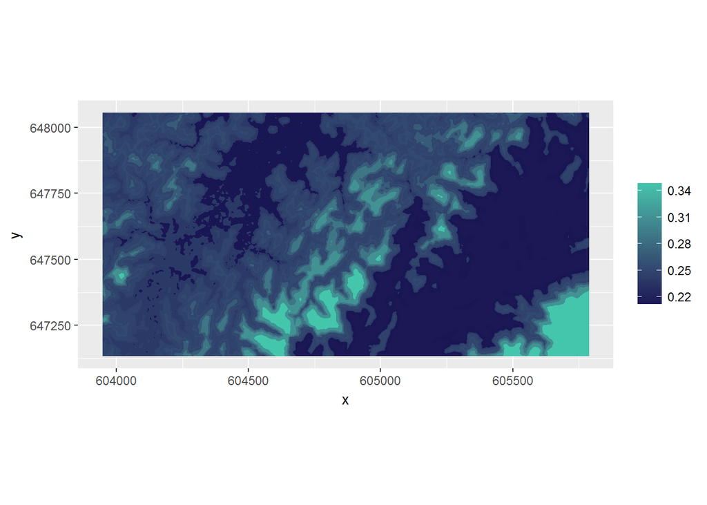

```r
ggSen <- as.data.frame(senPlot, xy = TRUE) # converting the raster to a data.frame
colnames(ggSen) <- c("x","y","z")
### Blue lagoon colours
ggplot(ggSen) + geom_raster(aes(x, y, fill=z)) +
  scale_fill_gradient(low="#191654", high="#43C6AC", name = "",
                      breaks=c(0.22, 0.25, 0.28, 0.31, 0.34)) +
  coord_fixed()
```

```r
#writeRaster(senPlot, "senPlot.tif", format = "GTiff")
```